# Tarea 6: comparacion de modelos

Nicolás Rojas y Francisca Villablanca

26-08-2021

# Preparación del ambiente de trabajo

```r
rm(list = ls())

library(readr)
library(dplyr)
library(tidyverse)
library(sf)
library(sp)
library(spdep)
library(rgdal)
library(rgeos)
library(tmap)
library(tmaptools)
library(spgwr)
library(grid)
library(gridExtra)
library(raster)
library(viridis)
library(spatstat)
library(leaflet)
library(rvest)
library(httr)
library(XML)
library(data.table)
library(devtools)
library(spatialreg)
library(car)
library(lmtest)
library(robustHD)
library(qpcR)
library(mblm)
library(RColorBrewer)
library(tidyverse)
```

```r
options(warn = -1,
        scipen = 999, # evitar notacion cientifica
        stringsAsFactors = FALSE)
```

```r
# latlon Utilizado a escala mundial
crs_latlon <- "+proj=longlat +datum=WGS84 +no_defs"

# utm utilizado a nivel regional (depende de la zona y hemisferio)
crs_utm <-"+proj=utm +zone=19 +south +datum=WGS84 +units=m +no_defs"
```

```r
# Codificamos la información necesaria
censo17 <-
  censo17 %>%
  mutate( # crear variables
    CODIGO_COMUNA   = COMUNA * 10 ^ 6,
    DISTRITO_CENSAL = DC * 10 ^ 4,
    CODIGO_AREA     = AREA * 10 ^ 3,
    ZC_LOC,
    COD_INE_15 = as.numeric(CODIGO_COMUNA + DISTRITO_CENSAL + CODIGO_AREA + ZC_LOC)
  ) %>%
  dplyr::select(COD_INE_15, COMUNA, P07, P08, P09, P15, P15A, ESCOLARIDAD, P18, DC)

# Nombramos las variables
colnames(censo17) <- c("ZONA", "COMUNA","PARENT", "SEXO", "EDAD", "EDUC_NVL", "EDUC_NVL_FIN", "ESCOLARIDAD", "RAMA_ECON", "DISTRITO")


head(censo17)
```

```
##         ZONA COMUNA PARENT SEXO EDAD EDUC_NVL EDUC_NVL_FIN ESCOLARIDAD
## 1 1101011001   1101      1    1   60       10            1          10
## 2 1101011001   1101      1    1   38       11            1          15
## 3 1101011001   1101      1    2   39       12            2          17
## 4 1101011001   1101      5    2   12        5            2           6
## 5 1101011001   1101      1    1   41       12            1          17
## 6 1101011001   1101      1    1   38        8            1          12
##   RAMA_ECON DISTRITO
## 1        H         1
## 2        C         1
## 3        O         1
## 4        98        1
## 5        G         1
## 6        B         1
```

```r
# Seleccionamos la informacion de concepcion para trabajar con menos datos
concepcion <-
  censo17 %>%
  dplyr::filter(COMUNA == 8101)

head(concepcion)
```

```
##         ZONA COMUNA PARENT SEXO EDAD EDUC_NVL EDUC_NVL_FIN ESCOLARIDAD
## 1 8101011001   8101      1    1   45       11            1          15
## 2 8101011001   8101      1    2   47       13            1          19
## 3 8101011001   8101      1    2   80        9            1          12
## 4 8101011001   8101      1    1   54       11            1          14
## 5 8101011001   8101      1    2   48        7            1          12
## 6 8101011001   8101      5    1   22       12            1          16
##   RAMA_ECON DISTRITO
## 1        M         1
## 2        O         1
## 3        98        1
## 4        Z         1
## 5        L         1
## 6        98        1
```

```r
# Ya rescatamos los datos de la comuna de interés, por lo que podemos descartar el censo17 completo.
rm(censo17)
```

```r
# Separamos la información de concepcion
viviendas_conce <-
    viviendas17 %>%
    dplyr::filter(COMUNA == 8101) %>%
    mutate( # crear variables
    CODIGO_COMUNA   = COMUNA * 10 ^ 6,
    DISTRITO_CENSAL = DC * 10 ^ 4,
    CODIGO_AREA     = AREA * 10 ^ 3,
    ZC_LOC,
    ZONA = as.numeric(CODIGO_COMUNA + DISTRITO_CENSAL + CODIGO_AREA + ZC_LOC),
    PERS_DORM = CANT_PER/P04,
    HACINAC = ifelse(PERS_DORM > 2.5,1,0)
    ) %>%
    group_by(ZONA) %>%
    summarise(
        HACINAC = sum(HACINAC)*100/n(),
        COMUNA = mean(COMUNA)
              )
# Ya rescatamos los datos de la comuna de interés, por lo que podemos descartar viviendas17.
rm(viviendas17)
```

Consolidamos la informacion de la comuna de interes en una solo objeto.

```r
#Consolidamos la información de la comuna de interés
concepcion <-
    left_join(concepcion, viviendas_conce, by = 'ZONA')

#Mantenemos las variables de interes
concepcion <- concepcion %>%
  dplyr::select(ZONA, COMUNA.x, PARENT, SEXO, EDAD, EDUC_NVL, EDUC_NVL_FIN, ESCOLARIDAD, RAMA_ECON, DISTRITO, HACINAC)

#Renombramos las variables
colnames(concepcion) <- c("ZONA", "COMUNA","PARENT", "SEXO", "EDAD", "EDUC_NVL", "EDUC_NVL_FIN", "ESCOLARIDAD", "RAMA_ECON", "DISTRITO", "HACINAC")

# Ya hemos consolidado la información en una sola BDD por lo que podemos descartar viviendas_conce.
rm(viviendas_conce)
```

```r
# Filtramos los valores que faltan
concepcion <-
  concepcion %>%
  dplyr::filter(ESCOLARIDAD != 98 & ESCOLARIDAD != 99)
```

```r
# Extraemos los datos de la comuna de interés (ae)
zonas17_concepcion <-
  zonas17 %>%
  dplyr::filter(COMUNA == 8101)
# ya que hemos rescatdo la información de la comuna de interés, podemos descartar la base total.
# rm(zonas17)
```

Categorizacion inicial de jefes de hogar con estudios universitarios incompletos.

Supuesto: aquellos que se encuentran en status de incompleto están cursando el nivel de estudios indicado.

```r
pob_preg <- concepcion %>%
    dplyr::filter(ESCOLARIDAD >= 12 & ESCOLARIDAD < 17)

escol_prom_univ <-
  pob_preg %>%
  group_by(ZONA) %>%
  summarise(
    ESCOL_SUM = sum(ESCOLARIDAD)
            )
```

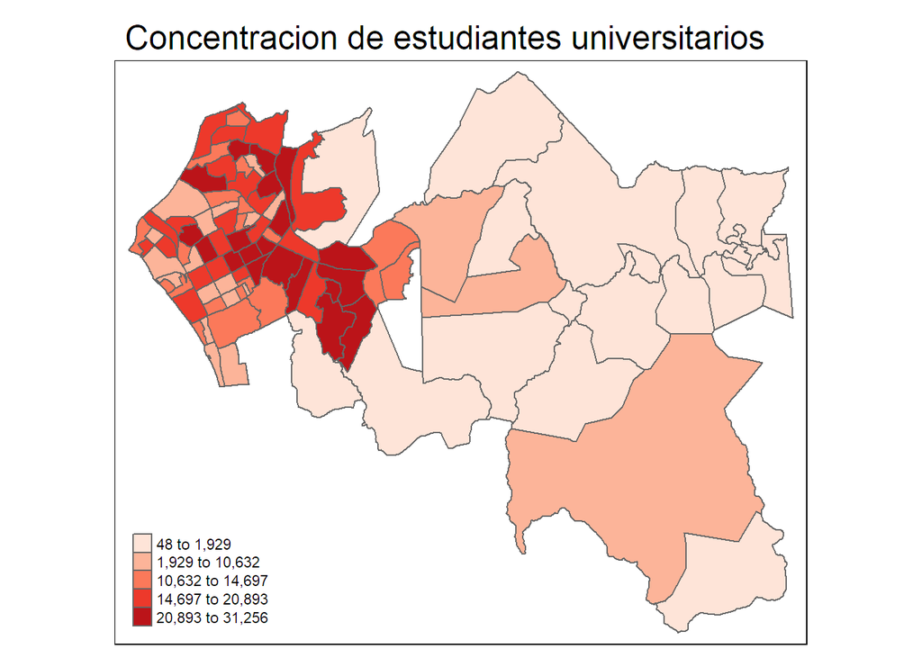

```r
# Graficamos el promedio de estudios de los jefes de hogar con estudios universitarios en la comuna de concepcion.
ae1 <- zonas17_concepcion %>%
    dplyr::select(COD_INE_15) %>%
    left_join(escol_prom_univ, by = c('COD_INE_15' = 'ZONA')) %>%
    dplyr::filter(!is.na(ESCOL_SUM))

#QUINTILES
tm_shape(ae1) +
  tm_fill("ESCOL_SUM", palette = "Reds", title="", n = 5, style = "quantile") +   #n=5 es el default
  tm_borders() +
  tm_layout(legend.position = c("left", "bottom"))+
  tm_layout(main.title = "Concentracion de estudiantes universitarios", title.size = 0.5, main.title.position = "left")
```

```r
# Separamos para ver que parte de la poblacion son estudiantes universitarios
# El segundo argumento define que no se ha completado el nivel educativo
pob_univ <-
    concepcion %>%
    dplyr::filter(EDUC_NVL > 11 & EDUC_NVL_FIN == 2) %>%
    group_by(ZONA) %>%
    summarise(
            ESCOL_PROM = mean(ESCOLARIDAD)
              )

ae <- zonas17_concepcion %>%
    dplyr::select(COD_INE_15) %>%
    left_join(pob_univ, by = c('COD_INE_15' = 'ZONA')) %>%
    dplyr::filter(!is.na(ESCOL_PROM))

## Crearemos el modelo en coordenadas utm y en formato espacial (requerido por el paquete)
ae_sf_univ <- st_as_sf(ae) %>%
  st_transform(crs_utm) %>%
  as_Spatial()

## Creacion de vecinos para la escolaridad promedio universitaria de los jefes de hogar de la comuna de interés.

# QUEEN NEIGHBORS
neighbours_queen_univ <- poly2nb(ae_sf_univ)
neighbours_queen_univ
```

```
## Neighbour list object:
## Number of regions: 94
## Number of nonzero links: 486
## Percentage nonzero weights: 5.500226
## Average number of links: 5.170213
```

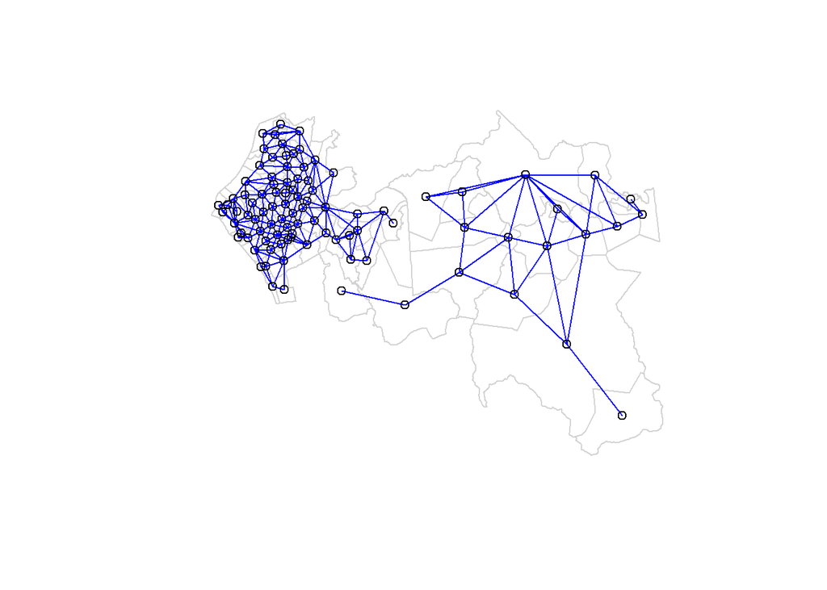

```r
# Plot
plot(ae_sf_univ, border = 'lightgrey')
plot(neighbours_queen_univ, coordinates(ae_sf_univ), add = TRUE, col = 'blue')
```

### I de Moran global

```r
list_q_univ <- nb2listw(neighbours_queen_univ)
list_q_univ
```

```
## Characteristics of weights list object:
## Neighbour list object:
## Number of regions: 94
## Number of nonzero links: 486
## Percentage nonzero weights: 5.500226
## Average number of links: 5.170213
##
## Weights style: W
## Weights constants summary:
##    n   nn S0       S1       S2
## W 94 8836 94 42.20763 391.5111
```

```r
globalMoran_q_univ <- moran.test(ae$ESCOL_PROM, list_q_univ)
globalMoran_q_univ
```

```
##
##  Moran I test under randomisation
##
## data:  ae$ESCOL_PROM
## weights: list_q_univ
##
## Moran I statistic standard deviate = -1.7552, p-value = 0.9604
## alternative hypothesis: greater
## sample estimates:
## Moran I statistic       Expectation          Variance
##      -0.122875060      -0.010752688       0.004080546
```

```r
globalMoran_q_univ[["estimate"]][["Moran I statistic"]]
```

```
## [1] -0.1228751
```

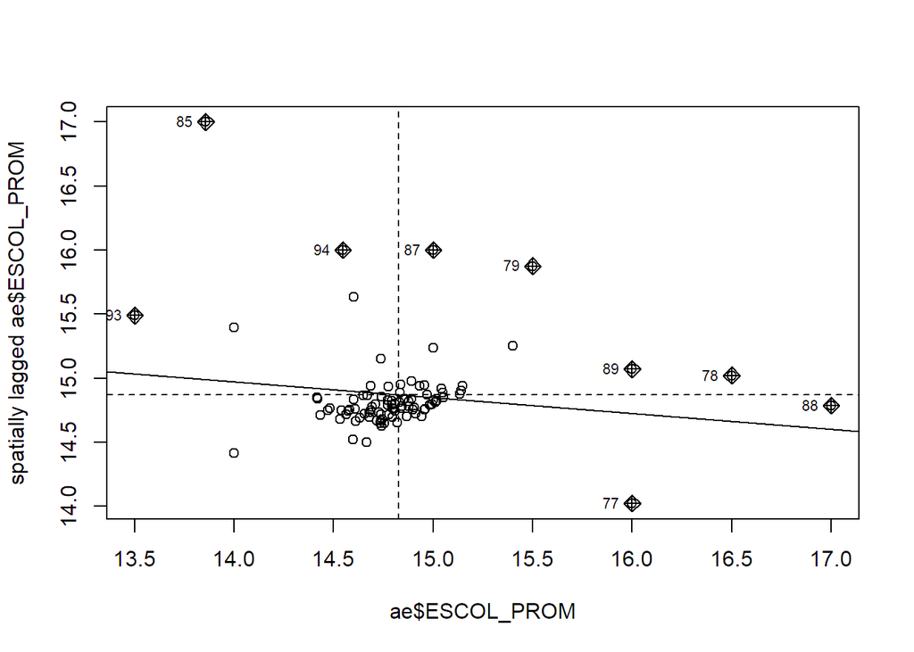

```r
moran <- moran.plot(ae$ESCOL_PROM, listw = nb2listw(neighbours_queen_univ, style = "W"))
```

### I DE MORAN LOCAL

```
## Variable(s) "Ii" contains positive and negative values, so midpoint is set to 0. Set midpoint = NA to show the full spectrum of the color palette.
```

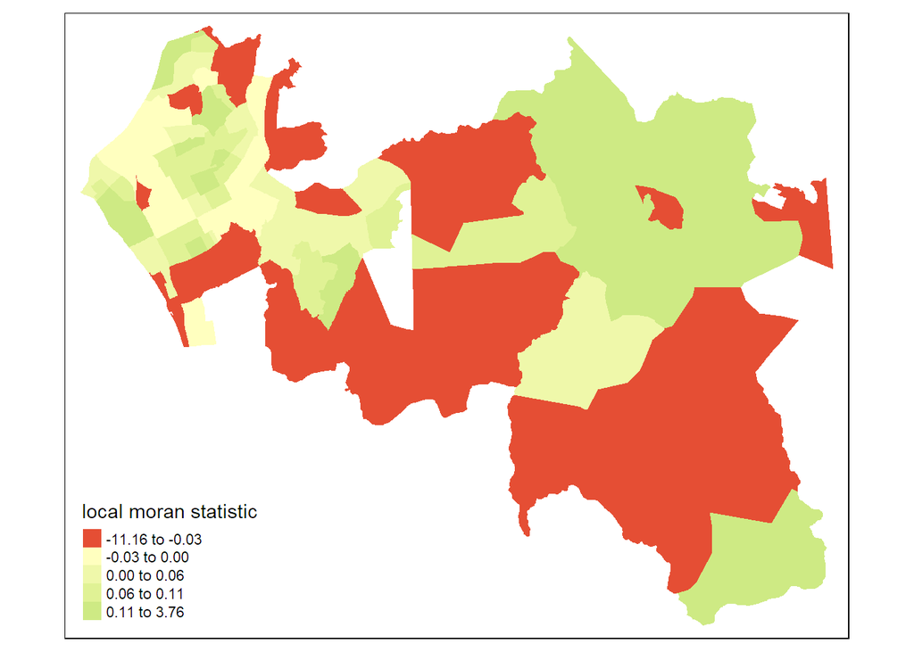

```r
local_univ <- localmoran(x = ae$ESCOL_PROM, listw = nb2listw(neighbours_queen_univ, style = "W"))

moran.map <- cbind(ae, local_univ)

tm_shape(moran.map) +
  tm_fill(col = "Ii",
          style = "quantile",
          title = "local moran statistic")
```

Ahora produciremos un mapa para detectar clústeres y outliers

```r
quadrant <- vector(mode = "numeric", length = nrow(local_univ))

# centers the variable of interest around its mean
m.zc <- ae$ESCOL_PROM - mean(ae$ESCOL_PROM)

# centers the local Moran's around the mean
m.local <- moran$wx- mean(moran$wx,na.rm = T)

# significance threshold
signif <- 0.01

# builds a data quadrant
quadrant[m.zc > 0 & m.local > 0] <- 1
quadrant[m.zc < 0 & m.local < 0] <- 1
quadrant[m.zc < 0 & m.local > 0] <- 1
quadrant[m.zc > 0 & m.local < 0] <- 1
quadrant[local_univ[, 5] > signif] <- 0


quadrant
```

```
##  [1] 0 0 0 0 0 0 0 0 0 0 0 0 0 0 0 0 0 0 0 0 0 0 0 0 0 0 0 0 0 0 0 0 0 0 0 0 0 0
## [39] 0 0 0 0 0 0 0 0 0 0 0 0 0 0 0 0 0 0 0 0 0 0 0 0 0 0 0 0 0 0 0 0 0 0 0 0 0 0
## [77] 1 0 1 1 0 0 0 0 1 0 1 0 0 0 0 0 1 1
```

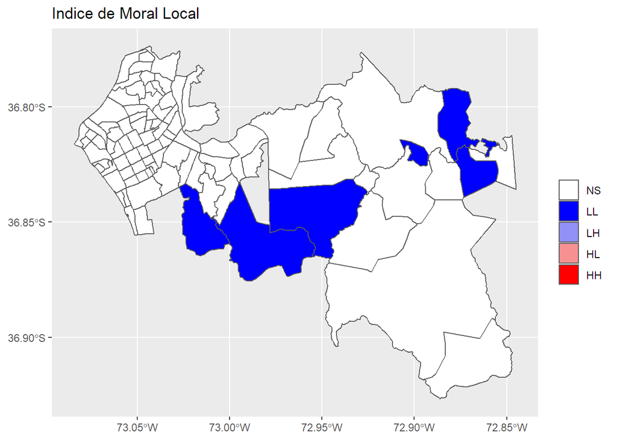

```r
# plot in r

ae_univ <- ae %>%
  dplyr::select(-COD_INE_15) %>%
  cbind(ae, quadrant) %>%
  mutate(quadrant = as.character(quadrant))


ggplot() +
  geom_sf(data = ae_univ, aes(fill = quadrant)) +
  scale_fill_manual(name = "", labels = c("NS", "LL", "LH", "HL", "HH"),
                    values = c(
                      "0" = "white",
                      "1" = "blue",
                      "2" = rgb(0, 0, 1, alpha = 0.4),
                      "3" = rgb(1, 0, 0, alpha = 0.4),
                      "4" = "red")) +
  ggtitle('Indice de Moral Local')
```

```r
pe_conce <-
  pe_2010_2020 %>%
  dplyr::filter(COD_COMUNA == 8101) %>%
  mutate(AÑO = as.numeric(AÑO)) %>%
  dplyr::filter(AÑO >= 2018) %>%
  dplyr::filter(USO_DESTIN == 'HABITACIONAL') %>%
  dplyr::filter(NUM_PISOS >= 5)

rm(pe_2010_2020)
```

Grafico PE 2018-2020 concepcion vs departamentos en arriendo

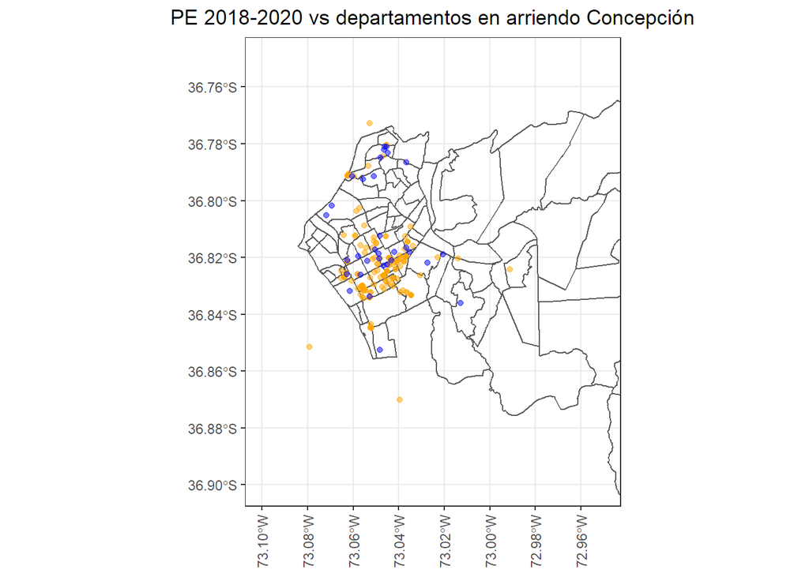

```r
grafo_base <-
  zonas17_concepcion %>%
  ggplot() +
  geom_sf(fill = NA) +
  theme_bw()

grafo_base +
  geom_sf(data = deptos_conce$geometry, color = alpha("orange", 0.5)) +
  geom_sf(data = pe_conce$geometry, color = alpha('blue', 0.5)) +
  ggtitle('PE 2018-2020 vs departamentos en arriendo Concepción') +
  coord_sf(xlim = c(-73.1,-72.95), ylim = c(-36.9,-36.75)) +
  theme(axis.text.x = element_text(angle = 90, vjust = 0.5, hjust=1)) +
  theme(plot.title = element_text(hjust = 0.5))
```

```r
#Creamos la variable UF/m2
deptos_conce$precio <- as.numeric(deptos_conce$precio)
deptos_conce$area_total <- as.numeric(deptos_conce$area_total)
deptos_conce$area_util <- as.numeric(deptos_conce$area_util)

class(deptos_conce$precio)
```

```
## [1] "numeric"
```

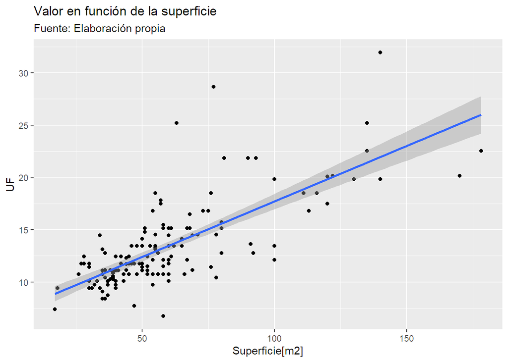

```r
#Creamos la variable UF/m2
precios <-
  deptos_conce %>%
    mutate(
      uf = (precio/29750),
      ufm2 = uf/area_total) %>%
  dplyr::filter(uf > 1) %>%
  dplyr::filter(area_total < 1000)

# Graficamos la relacion UF - M2
ggplot(data = precios, aes(x = area_total, y = uf)) +
  geom_point() +
  geom_smooth(method = 'lm', se = TRUE)+
  labs(x = 'Superficie[m2]',
       y = 'UF',
       title = 'Valor en función de la superficie',
       subtitle = 'Fuente: Elaboración propia')
```

```r
# Es de esperar que la relacion varie muy poco ya que todos se concentran en sectores similares
```

```r
precios <- precios %>%
  mutate(ln_uf = log(uf)) %>%
  mutate(area_ln = log(area_total))
```

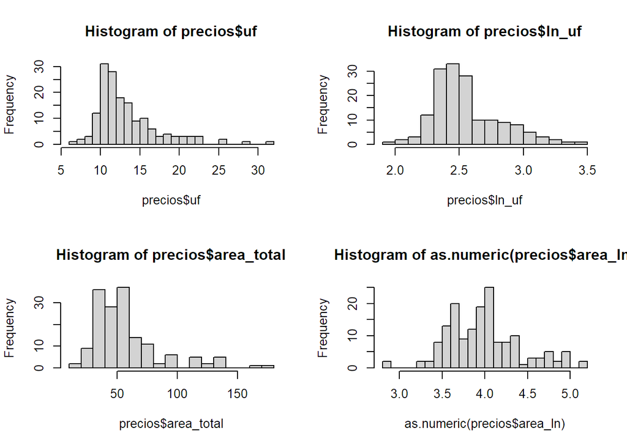

```r
par(mfrow = c(2,2)) #Permite graficar más de una imagen por pantalla
hist(precios$uf, breaks = 20)
hist(precios$ln_uf, breaks = 20)
hist(precios$area_total, breaks = 20)
hist(as.numeric(precios$area_ln), breaks = 20)
```

```
## [1] "numeric"
```

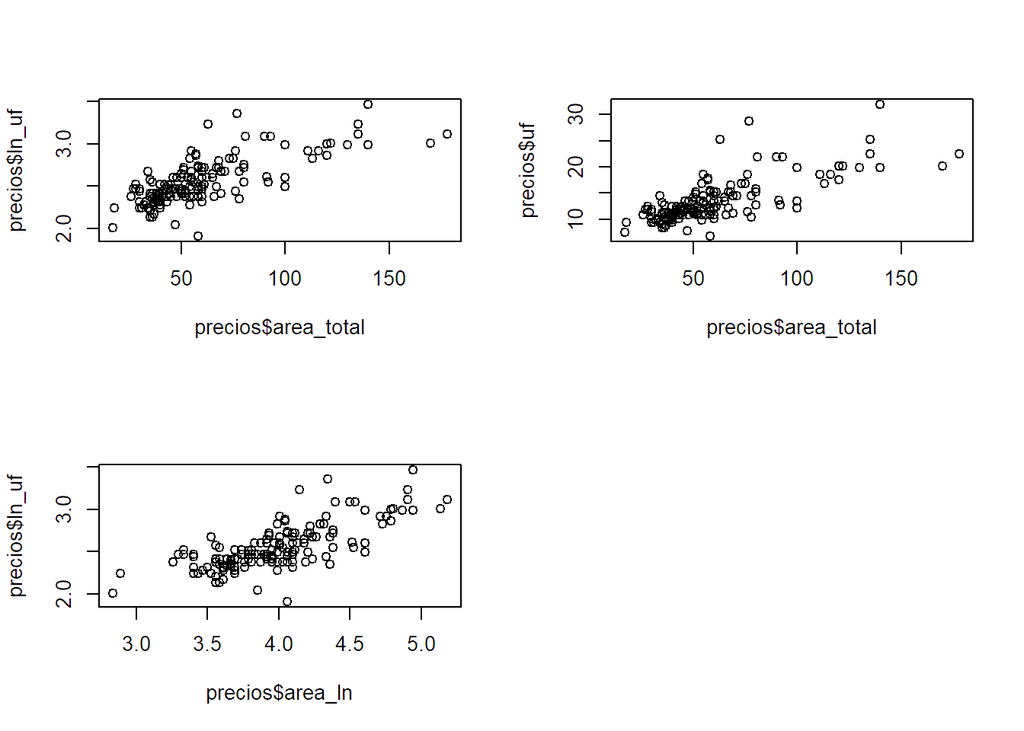

```r
plot(precios$area_total, precios$ln_uf)
plot(precios$area_total, precios$uf)
plot(precios$area_ln, precios$ln_uf)

class(precios$area_ln)
```

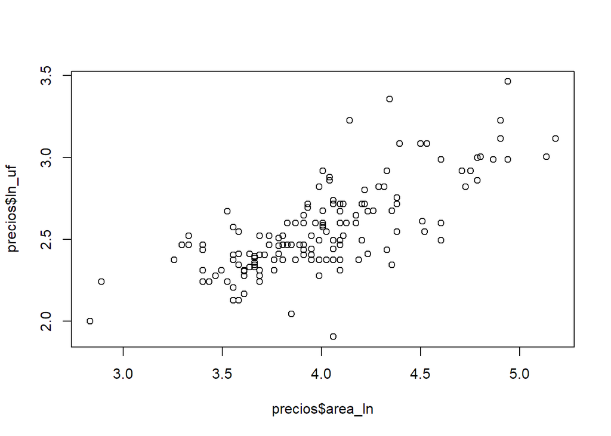

```r
plot(precios$area_ln, precios$ln_uf)
```

```r
# Distancia entre propiedades y variables de interes
dist_parq <- st_distance(precios, parques)
```

```
## st_as_s2(): dropping Z and/or M coordinate
```

```r
dist_superm <- st_distance(precios, supermercado)
```

```
## st_as_s2(): dropping Z and/or M coordinate
```

```r
dist_hosp <- st_distance(precios, centros_salud)
```

```
## st_as_s2(): dropping Z and/or M coordinate
```

```r
dist_univ <- st_distance(precios, universidades)
```

```
## st_as_s2(): dropping Z and/or M coordinate
```

```r
# Agregamos las distancias al DF
# precios$parque <- parques$Name[max.col(-dist_parq)]
# precios$superm <- supermercado$Name[max.col(-dist_superm)]
# precios$univ <- universidades$Name[max.col(-dist_univ)]
# precios$c_salud <- centros_salud$Name[max.col(-dist_hosp)]
```

```r
#Y recolectamos la distancia
precios$superm <- apply(dist_superm, 1, min)
precios$c_salud <- apply(dist_hosp, 1, min)
precios$univ <- apply(dist_univ, 1, min)
precios$parque <- apply(dist_parq, 1, min)
```

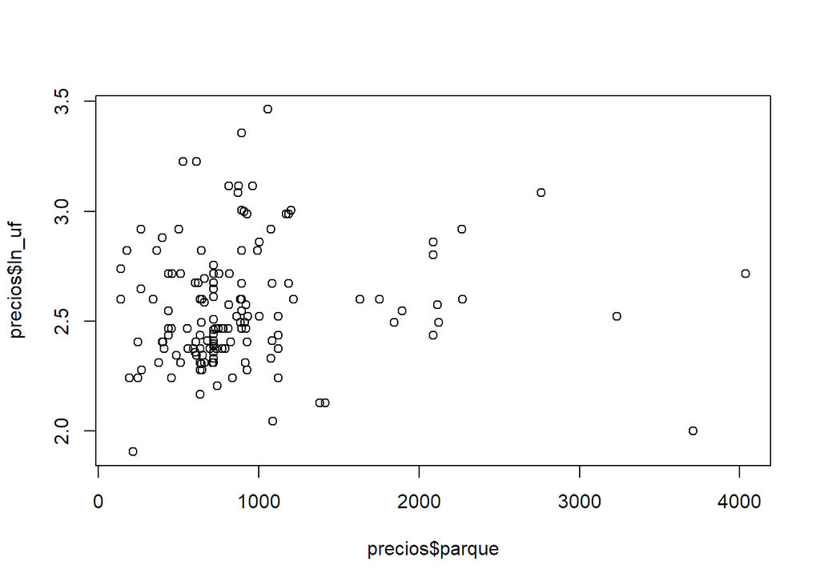

```r
plot(precios$parque, precios$ln_uf)
```

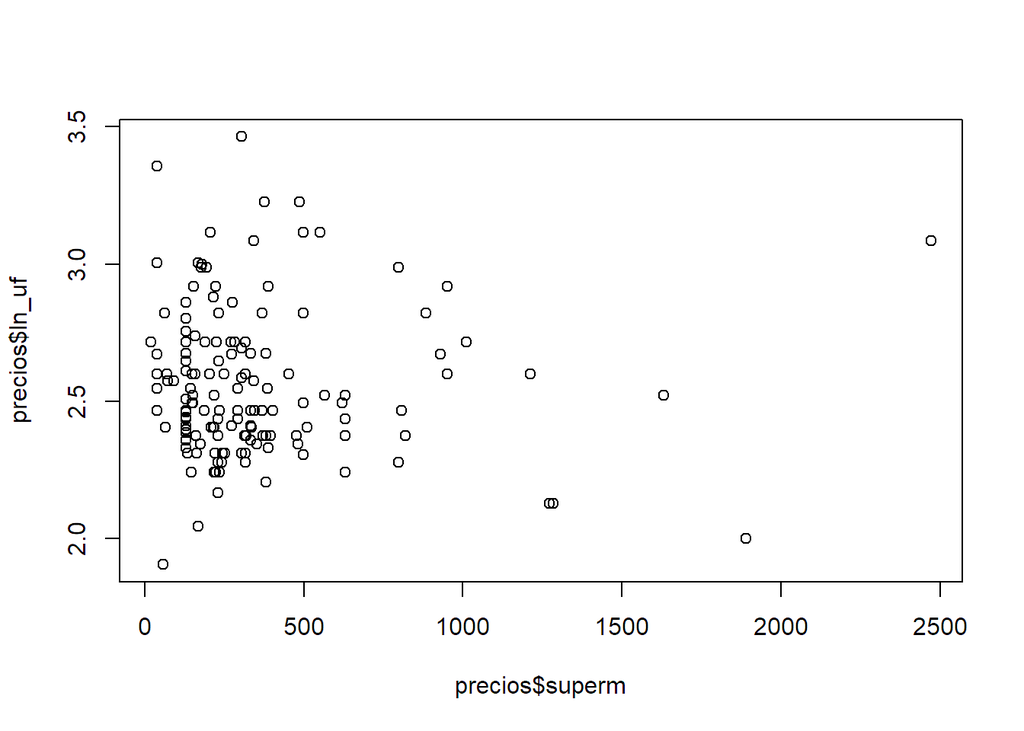

```r
plot(precios$superm, precios$ln_uf)
```

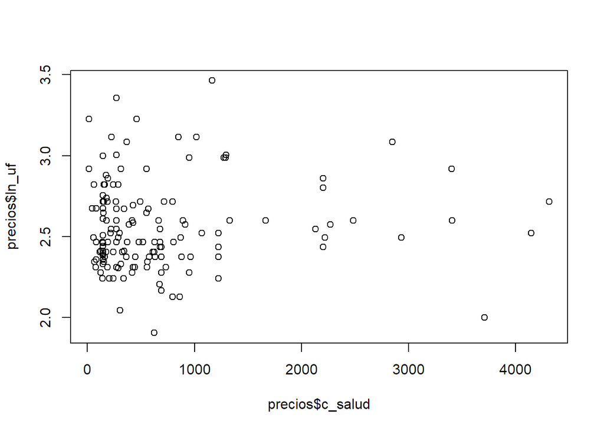

```r
plot(precios$c_salud, precios$ln_uf)
```

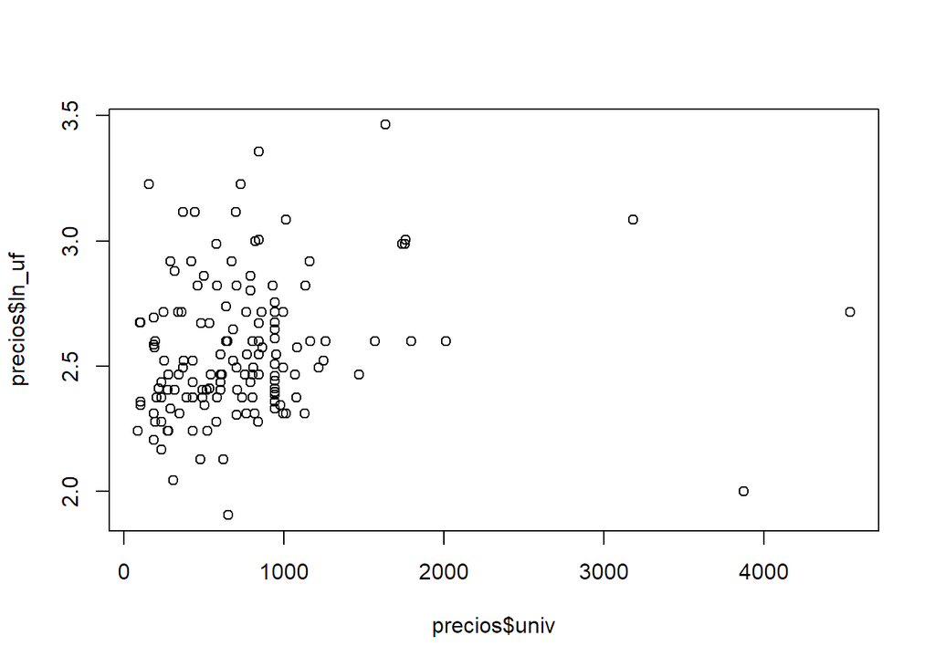

```r
plot(precios$univ, precios$ln_uf)
```

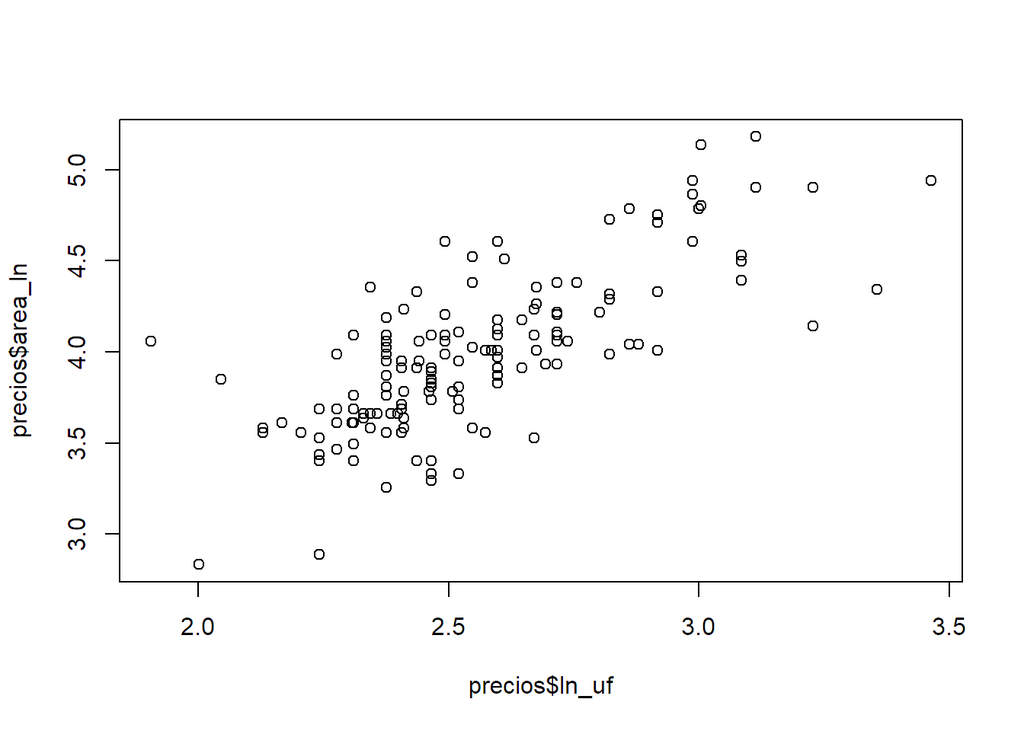

```r
par(mfrow = c(1,1))
plot(precios$ln_uf, precios$area_ln)
```

```r
summary(precios)
```

```
##      precio         bedrooms          bathrooms           area_total
##  Min.   :200000   Length:159         Length:159         Min.   : 17.00
##  1st Qu.:320000   Class :character   Class :character   1st Qu.: 39.50
##  Median :360000   Mode  :character   Mode  :character   Median : 52.00
##  Mean   :396498                                         Mean   : 58.84
##  3rd Qu.:436000                                         3rd Qu.: 65.50
##  Max.   :950000                                         Max.   :178.00
##    area_util          dir                     geometry         uf
##  Min.   : 17.00   Length:159         POINT        :159   Min.   : 6.723
##  1st Qu.: 37.00   Class :character   epsg:4326    :  0   1st Qu.:10.756
##  Median : 50.00   Mode  :character   +proj=long...:  0   Median :12.101
##  Mean   : 56.21                                          Mean   :13.328
##  3rd Qu.: 64.00                                          3rd Qu.:14.655
##  Max.   :153.00                                          Max.   :31.933
##       ufm2            ln_uf          area_ln          superm
##  Min.   :0.1159   Min.   :1.905   Min.   :2.833   Min.   :  19.52
##  1st Qu.:0.2042   1st Qu.:2.375   1st Qu.:3.676   1st Qu.: 149.53
##  Median :0.2437   Median :2.493   Median :3.951   Median : 243.56
##  Mean   :0.2495   Mean   :2.552   Mean   :3.979   Mean   : 349.06
##  3rd Qu.:0.2788   3rd Qu.:2.685   3rd Qu.:4.182   3rd Qu.: 383.95
##  Max.   :0.5229   Max.   :3.464   Max.   :5.182   Max.   :2471.87
##     c_salud             univ             parque
##  Min.   :  15.33   Min.   :  88.09   Min.   : 140.6
##  1st Qu.: 180.01   1st Qu.: 356.87   1st Qu.: 618.1
##  Median : 371.21   Median : 653.27   Median : 738.2
##  Mean   : 673.63   Mean   : 732.13   Mean   : 887.0
##  3rd Qu.: 764.36   3rd Qu.: 942.46   3rd Qu.: 928.0
##  Max.   :4312.39   Max.   :4537.88   Max.   :4035.8
```

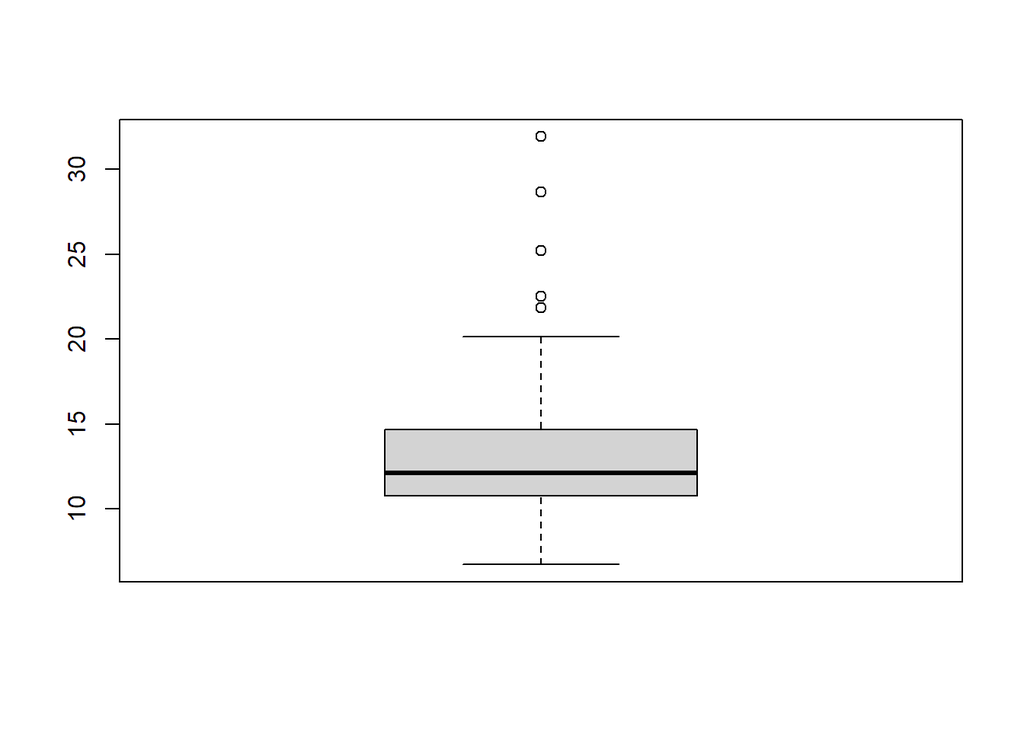

```r
boxplot(precios$uf)
```

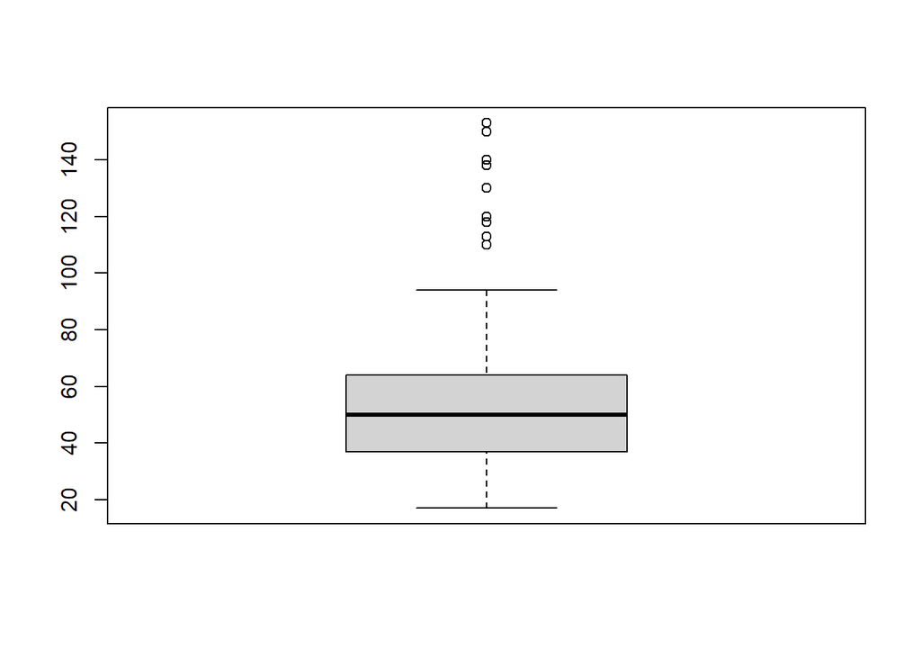

```r
boxplot(precios$area_util)
```

Dado a que encontramos la presencia de outliers, definimos que el rango aceptable para area util de los departamentos tendrá un maximo de 100m2. Esto se hace con el fin de refinar el modelo.

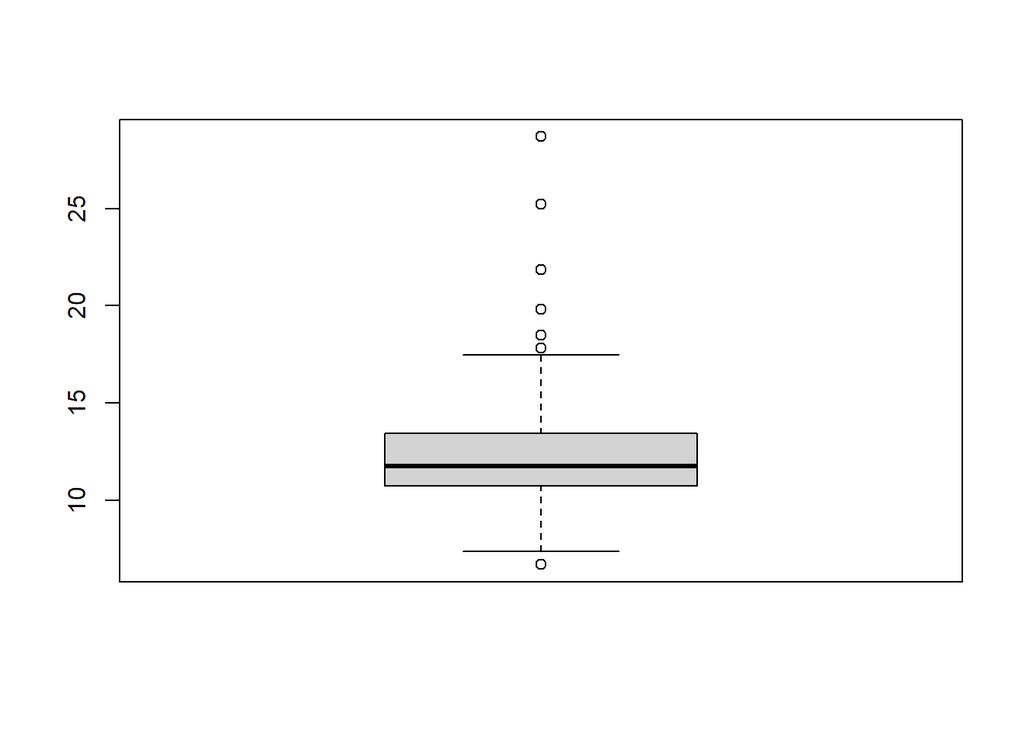

```r
precios <-
  precios %>%
  dplyr::filter(area_util <= 100)

boxplot(precios$uf)
```

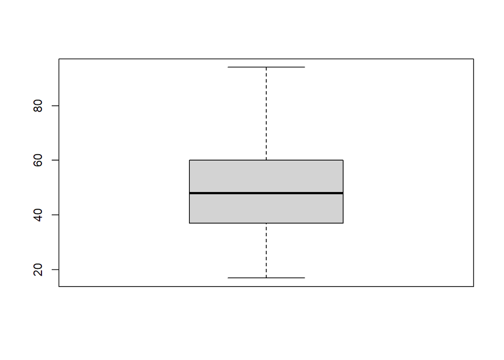

```r
boxplot(precios$area_util)
```

### Modelo de precios hedónico

```r
mean_preg <-
  pob_preg %>%
  group_by(ZONA) %>%
  summarise(
    ESCOL_PROM = mean(ESCOLARIDAD)
            )
```

```r
f1 <- formula(ln_uf ~ area_util + bathrooms + bedrooms + parque + superm + c_salud + univ)

m1 <- lm(f1, data = precios)
summary(m1)
```

```
##
## Call:
## lm(formula = f1, data = precios)
##
## Residuals:
##      Min       1Q   Median       3Q      Max
## -0.56905 -0.10123 -0.00708  0.10170  0.61317
##
## Coefficients:
##                 Estimate   Std. Error t value             Pr(>|t|)
## (Intercept)  2.054866887  0.063897122  32.159 < 0.0000000000000002 ***
## area_util    0.007111725  0.001478996   4.808           0.00000398 ***
## bathrooms2   0.009673111  0.047101021   0.205                0.838
## bathrooms3   0.037760192  0.123204752   0.306                0.760
## bedrooms2    0.066081491  0.049152663   1.344                0.181
## bedrooms3    0.102173203  0.073448568   1.391                0.166
## parque       0.000071985  0.000058291   1.235                0.219
## superm      -0.000006585  0.000053071  -0.124                0.901
## c_salud     -0.000041154  0.000041290  -0.997                0.321
## univ         0.000027132  0.000032956   0.823                0.412
## ---
## Signif. codes:  0 '***' 0.001 '**' 0.01 '*' 0.05 '.' 0.1 ' ' 1
##
## Residual standard error: 0.1765 on 136 degrees of freedom
## Multiple R-squared:  0.4356, Adjusted R-squared:  0.3982
## F-statistic: 11.66 on 9 and 136 DF,  p-value: 0.0000000000001867
```

```r
f2 <- formula(ln_uf ~ area_util + bathrooms + bedrooms + superm + univ)

m2 <- lm(f2, data = precios)
summary(m2)
```

```
##
## Call:
## lm(formula = f2, data = precios)
##
## Residuals:
##      Min       1Q   Median       3Q      Max
## -0.62428 -0.08822 -0.01134  0.10798  0.63133
##
## Coefficients:
##                 Estimate   Std. Error t value             Pr(>|t|)
## (Intercept)  2.075147529  0.061640520  33.665 < 0.0000000000000002 ***
## area_util    0.007407277  0.001456950   5.084           0.00000118 ***
## bathrooms2   0.014835455  0.046810032   0.317                0.752
## bathrooms3   0.056678624  0.121873219   0.465                0.643
## bedrooms2    0.048510137  0.046947137   1.033                0.303
## bedrooms3    0.074058720  0.069345976   1.068                0.287
## superm      -0.000001329  0.000048748  -0.027                0.978
## univ         0.000038383  0.000029059   1.321                0.189
## ---
## Signif. codes:  0 '***' 0.001 '**' 0.01 '*' 0.05 '.' 0.1 ' ' 1
##
## Residual standard error: 0.1762 on 138 degrees of freedom
## Multiple R-squared:  0.4293, Adjusted R-squared:  0.4003
## F-statistic: 14.83 on 7 and 138 DF,  p-value: 0.00000000000002507
```

```r
f3 <- formula(ln_uf ~ area_util + bathrooms + bedrooms)

m3 <- lm(f3, data = precios)
summary(m3)
```

```
##
## Call:
## lm(formula = f3, data = precios)
##
## Residuals:
##      Min       1Q   Median       3Q      Max
## -0.62513 -0.09978 -0.00844  0.10301  0.64211
##
## Coefficients:
##             Estimate Std. Error t value             Pr(>|t|)
## (Intercept) 2.100830   0.058056  36.187 < 0.0000000000000002 ***
## area_util   0.007410   0.001455   5.095           0.00000111 ***
## bathrooms2  0.024394   0.046426   0.525                0.600
## bathrooms3  0.077794   0.121009   0.643                0.521
## bedrooms2   0.042629   0.046833   0.910                0.364
## bedrooms3   0.069586   0.069127   1.007                0.316
## ---
## Signif. codes:  0 '***' 0.001 '**' 0.01 '*' 0.05 '.' 0.1 ' ' 1
##
## Residual standard error: 0.1763 on 140 degrees of freedom
## Multiple R-squared:  0.4198, Adjusted R-squared:  0.3991
## F-statistic: 20.26 on 5 and 140 DF,  p-value: 0.000000000000003576
```

Podemos observar que:

modelo 1 y 2: Las variables de distancia a supermercados y universidades no presentan un grado relevanete de multicolinealidad con ninguna de las otras variables. Es decir, ambas variables mencionadas poseen un poder explicativo independiente entre ellas.

modelo 1: Es importante notar que la distancia a parques y centros de salud en el primer modelo presentan un grado de multicolinealidad considerable.

modelo 1, 2, 3: tiene sentido notar que hay un grado de multicolinealidad entre las variables ‘area_util’, ‘bathrooms’ y ‘bedrooms’ ya que estas dos ultimas variables estan consideradas dentro del área util del modelo.

```r
car::vif(m1)
```

```
##               GVIF Df GVIF^(1/(2*Df))
## area_util 2.565097  1        1.601592
## bathrooms 2.983235  2        1.314232
## bedrooms  3.202099  2        1.337700
## parque    5.850941  1        2.418872
## superm    1.603621  1        1.266341
## c_salud   5.381566  1        2.319820
## univ      1.773001  1        1.331541
```

```r
car::vif(m2)
```

```
##               GVIF Df GVIF^(1/(2*Df))
## area_util 2.497780  1        1.580437
## bathrooms 2.923308  2        1.307581
## bedrooms  2.817005  2        1.295528
## superm    1.357635  1        1.165176
## univ      1.383256  1        1.176119
```

```r
car::vif(m3)
```

```
##               GVIF Df GVIF^(1/(2*Df))
## area_util 2.484328  1        1.576175
## bathrooms 2.847919  2        1.299068
## bedrooms  2.770784  2        1.290181
```

Para estudiar si existe algun grado de autocorrelacion entre los residuos de cada modelo regresivo, ocupamos el Durbin-Watson test. Como se puede observar en los siguientes resultados, ninguno de los modelos presenta un valor DW menor a 1, demostrando que no hay un grado problematico de autocorrelacion entre los errores de ninguno de los modelos. Y, al presentar DW menores a 2 pero considerablemente mayores a 1, podemos interpretar que los tres modelos tienen cierto grado de autocorrelacion positiva en los errores.

Adicionalmente, es importante notar que en ninguno de los modelos hay suficiente evidencia estadistica para poder rechazar la hipotesis nula del modelo.

```r
dwtest(m1)
```

```
##
##  Durbin-Watson test
##
## data:  m1
## DW = 1.7582, p-value = 0.06598
## alternative hypothesis: true autocorrelation is greater than 0
```

```r
dwtest(m2)
```

```
##
##  Durbin-Watson test
##
## data:  m2
## DW = 1.7981, p-value = 0.104
## alternative hypothesis: true autocorrelation is greater than 0
```

```r
dwtest(m3)
```

```
##
##  Durbin-Watson test
##
## data:  m3
## DW = 1.7894, p-value = 0.09492
## alternative hypothesis: true autocorrelation is greater than 0
```

Para observar la presencia de homocedasticidad, ocupamos el modelo Breusch-Pagan. Lo primero que podemos observar que existe suficiente evidencia estadística para rechazar la hipotesis nula (H0: Hay homocedasticidad) en los tres modelos. Es decir, la varianza de los errores no es constante entre todas las observaciones.

```r
bptest(m1)
```

```
##
##  studentized Breusch-Pagan test
##
## data:  m1
## BP = 20.172, df = 9, p-value = 0.01688
```

```r
bptest(m2)
```

```
##
##  studentized Breusch-Pagan test
##
## data:  m2
## BP = 21.777, df = 7, p-value = 0.002775
```

```r
bptest(m3)
```

```
##
##  studentized Breusch-Pagan test
##
## data:  m3
## BP = 24.208, df = 5, p-value = 0.000198
```

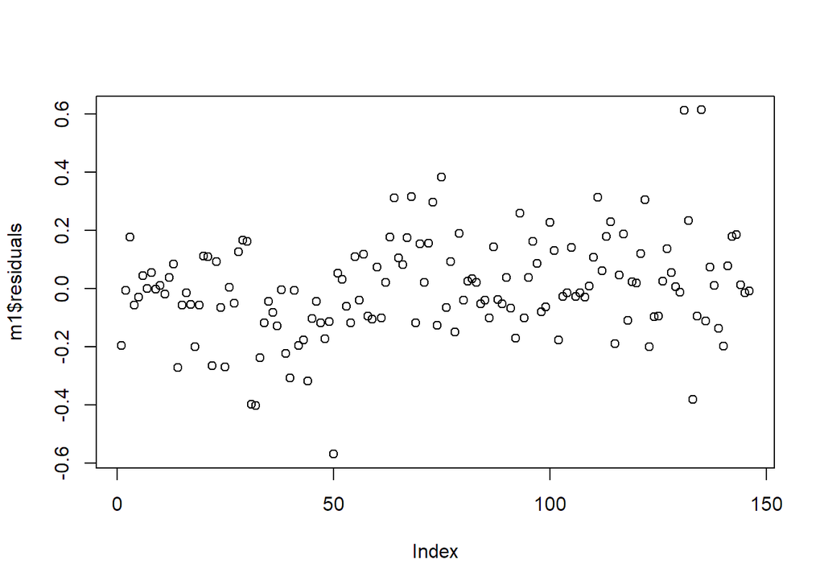

```r
plot(m1$residuals)
```

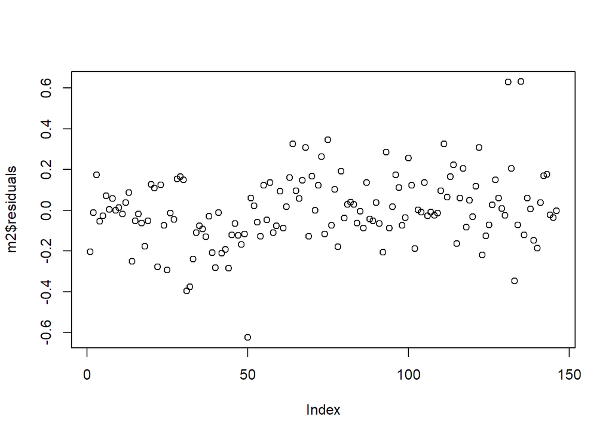

```r
plot(m2$residuals)
```

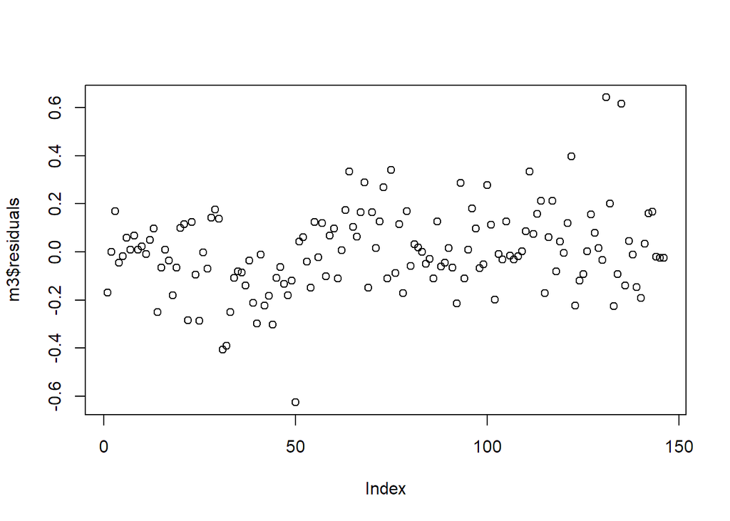

```r
plot(m3$residuals)
```

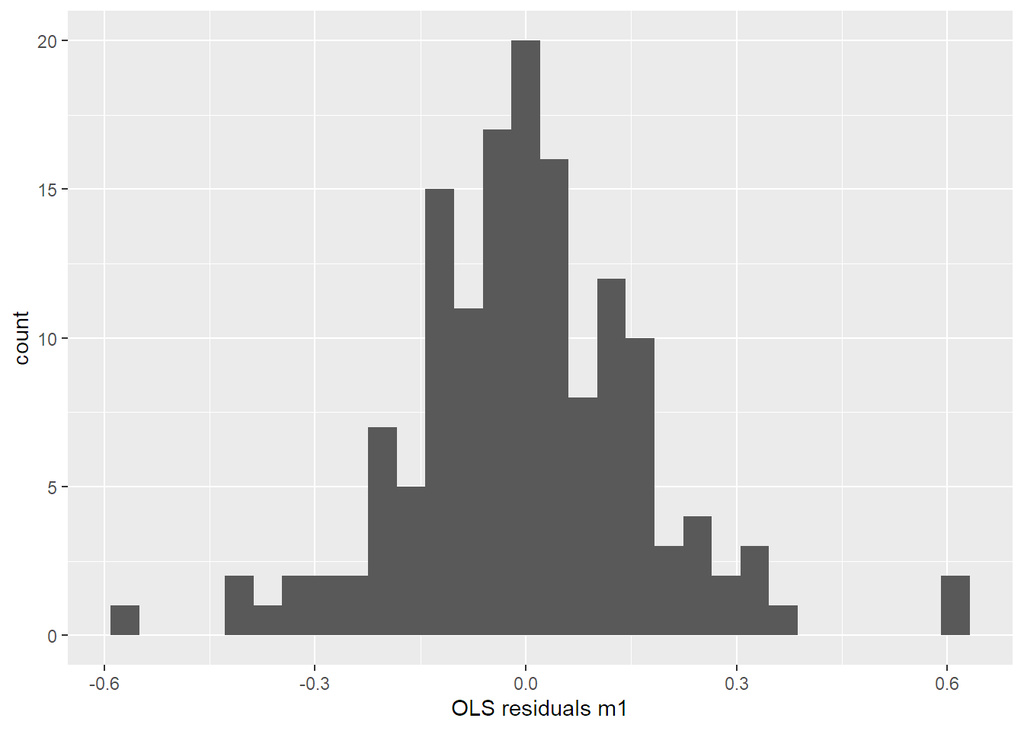

```r
ggplot() +
  geom_histogram(mapping = aes(x = m1$residuals)) +
  xlab("OLS residuals m1")
```

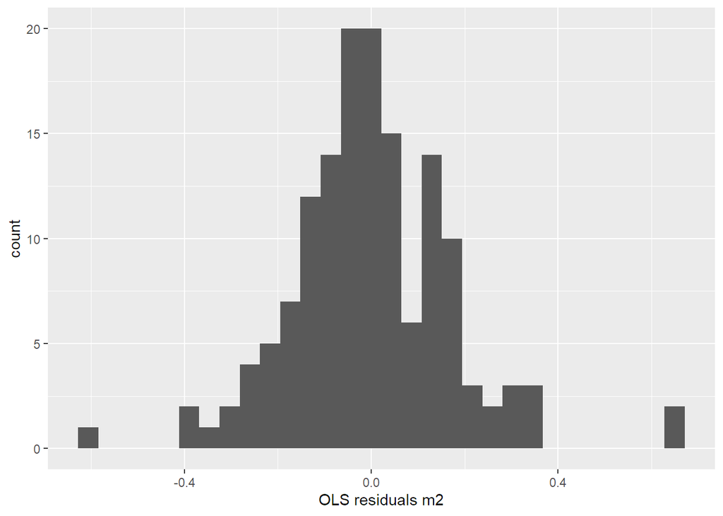

```r
ggplot() +
    geom_histogram(mapping = aes(x = m2$residuals)) +
  xlab("OLS residuals m2")
```

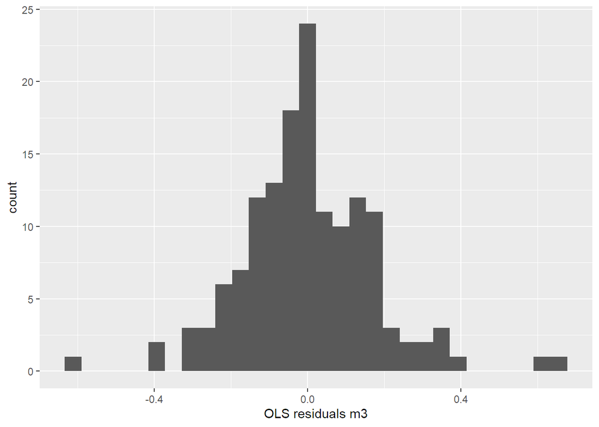

```r
ggplot() +
    geom_histogram(mapping = aes(x = m3$residuals)) +
  xlab("OLS residuals m3")
```

### Modelo 1:

Al observar el OLS del primer modelo, podemos notar en el grafico ‘Normal Q-Q’ que la distribucion de los residuos estandarizados siguen una distribucion normal en la mayor parte de los datos, pero, presentando un grado de heterocedasticidad en las colas, sobre todo la derecha. Es importante notar esto ya que aquellos datos pareciesen ser outliers, por lo que es necesario un posterior análisis para considerar su descarte.

En el grafico ‘Residuals vs Fitted’ podemos notar que la linealidad de los residuos pudiese ser explicada por que hay pocas no linealidades no capturadas por el modelo.

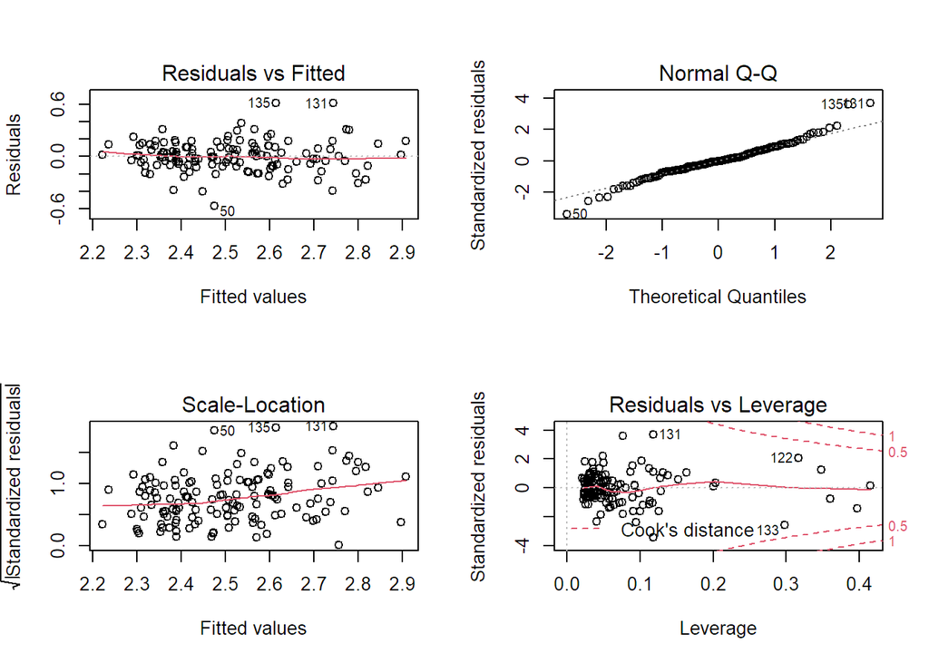

```r
par(mfrow = c(2, 2))
plot(m1)
```

### Modelo 2:

En los siguientes gráficos, tenemos conclusiones similares en ‘Residuals vs Fitted’ y en ‘Normal Q-Q’, Sin embargo, en el grafico ‘Residuals vs Leverage’ podemos notar que la distribución de los residuos sigue una forma menos lienal que en el modelo 1.

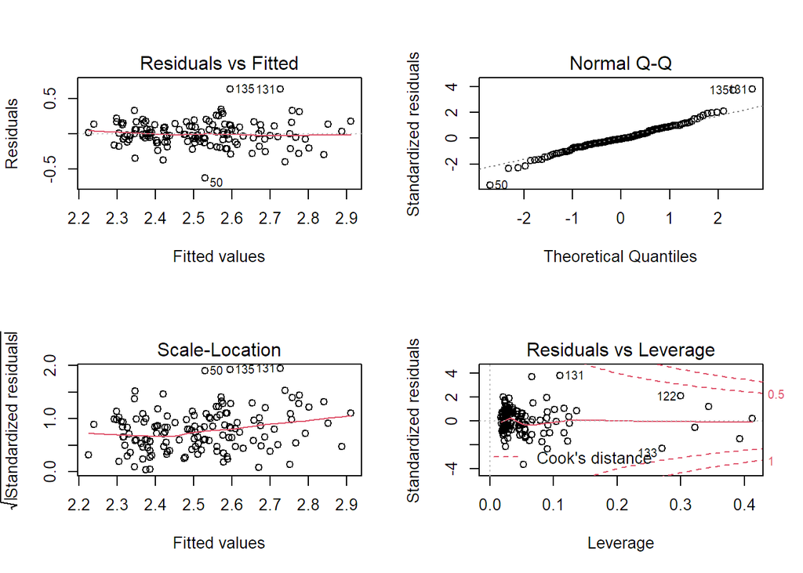

```r
par(mfrow = c(2,2))
plot(m2)
```

### Modelo 3:

En este modelo, lo principal que podemos observar son la perdida de linealidad constante entre los residuos del gráfico ‘Residuals vs Fittet’, al igual que en ‘Residuals vs Leverage’.

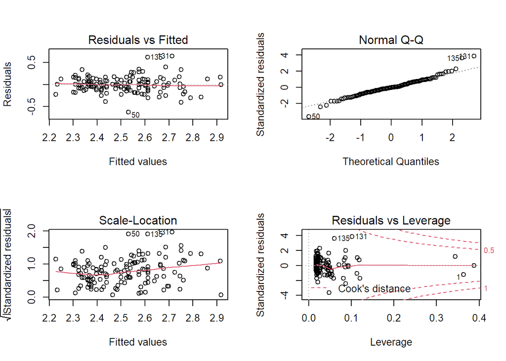

```r
par(mfrow = c(2,2))
plot(m3)
```

Sabiendo que la distancia de Cook nos permite categorizar las observaciones de los residuos como outliers, podemos notar que el primer modelo es aquel que, al seguir una mejor distribucion de los residuos, permite un mejor uso del criterio.

## Mapeo de los residuos OLS

### Modelo 1

```r
precios$olsresid <- m1$residuals

tm_shape(zonas17_concepcion) +
  tm_polygons('#f0f0f0f0', border.alpha = 0.2) +
  tm_shape(precios) +
  tm_dots("olsresid", size = 0.1)
```

```
## Variable(s) "olsresid" contains positive and negative values, so midpoint is set to 0. Set midpoint = NA to show the full spectrum of the color palette.
```

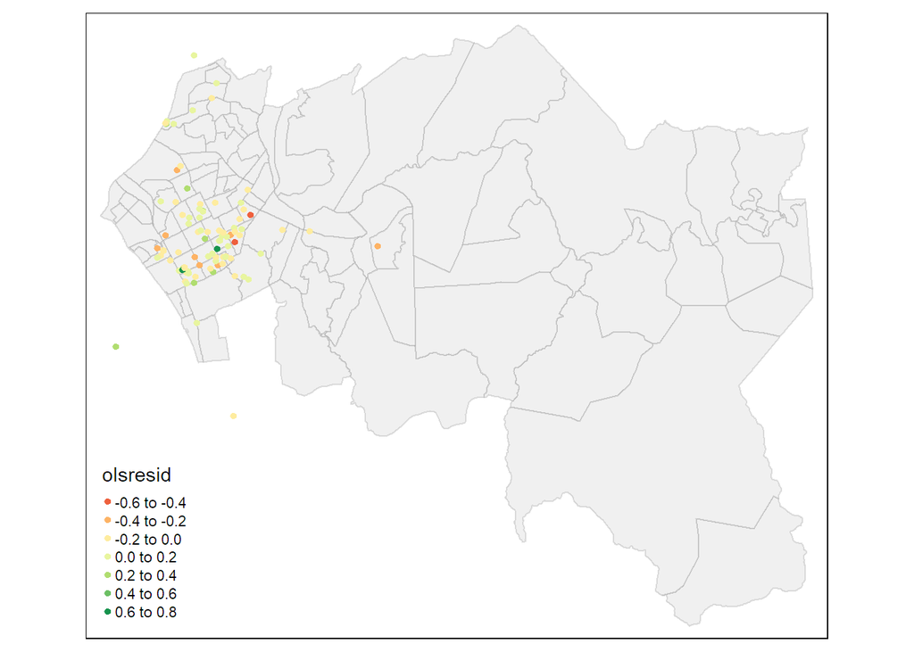

### Modelo 2

```r
precios$olsresid2 <- m2$residuals

tm_shape(zonas17_concepcion) +
  tm_polygons('#f0f0f0f0', border.alpha = 0.2, ) +
  tm_shape(precios) +
  tm_dots("olsresid2", size = 0.2)
```

```
## Variable(s) "olsresid2" contains positive and negative values, so midpoint is set to 0. Set midpoint = NA to show the full spectrum of the color palette.
```

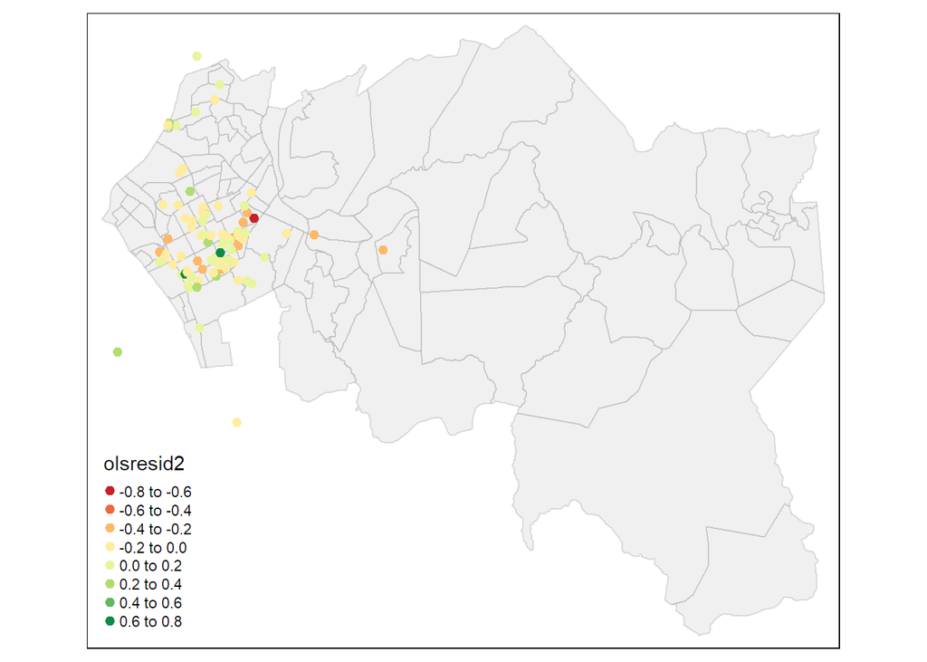

### Modelo 3

```r
precios$olsresid3 <- m3$residuals

tm_shape(zonas17_concepcion) +
  tm_polygons('#f0f0f0f0', border.alpha = 0.2, ) +
  tm_shape(precios) +
  tm_dots("olsresid3", size = 0.2)
```

```
## Variable(s) "olsresid3" contains positive and negative values, so midpoint is set to 0. Set midpoint = NA to show the full spectrum of the color palette.
```

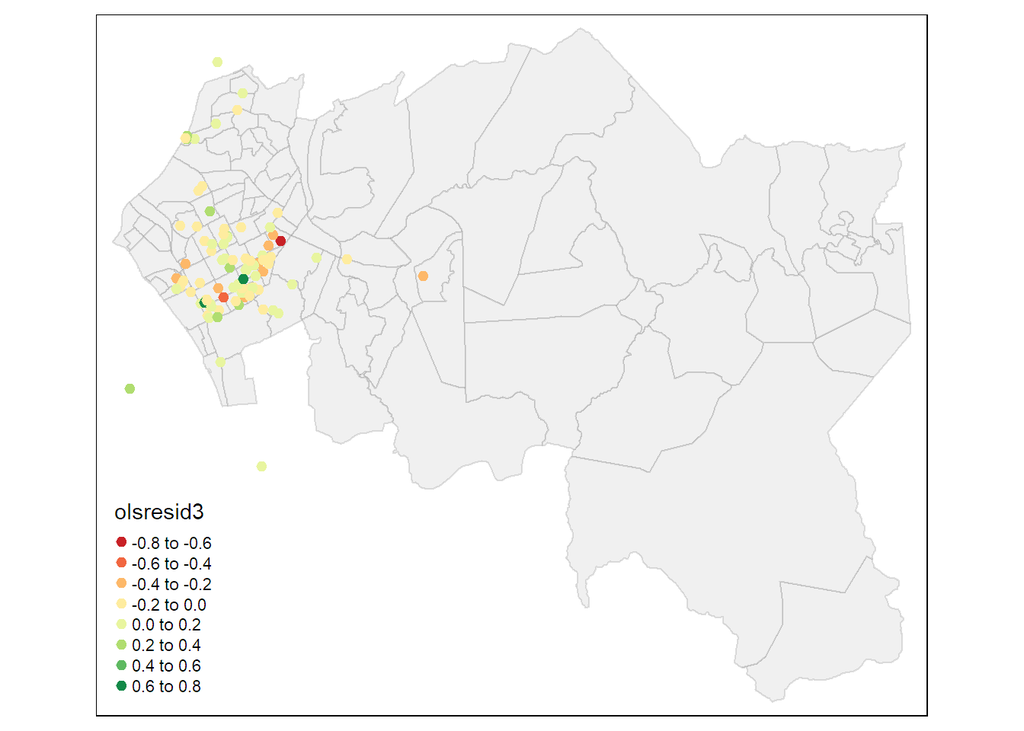

## Mapeo de los residuos estandarizados

### Modelo 1

```r
# STD RESIDUALS
precios <- precios %>%
  mutate(std_resid = standardize(as.numeric(precios$olsresid)))

summary(precios$std_resid)
```

```
##     Min.  1st Qu.   Median     Mean  3rd Qu.     Max.
## -3.32965 -0.59234 -0.04145  0.00000  0.59505  3.58780
```

```r
tm_shape(zonas17_concepcion) +
  tm_polygons('#f0f0f0f0', border.alpha = 0.2) +
  tm_shape(precios) +
  tm_dots("std_resid", size=0.1)
```

```
## Variable(s) "std_resid" contains positive and negative values, so midpoint is set to 0. Set midpoint = NA to show the full spectrum of the color palette.
```

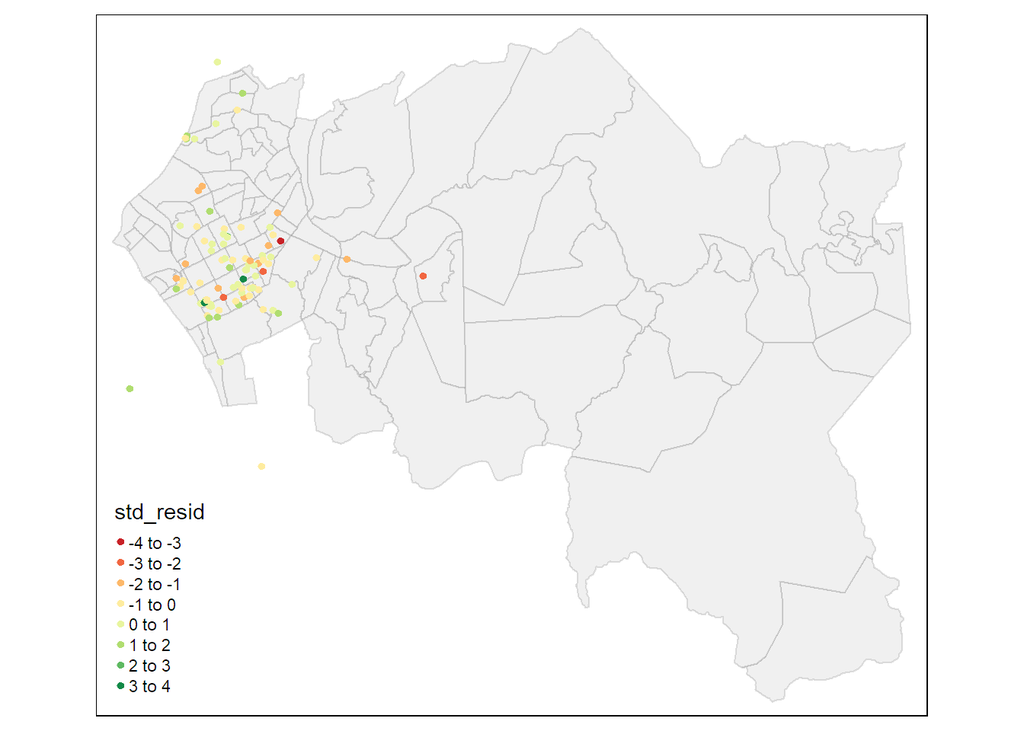